# Practicum

Richa Gupta

13/02/2020

### Reading the dataset

I am for the purposes of the assignment using only a subset of the data with first 500 rows.

```r
setwd("~/Desktop/Practicum")
dataset <- read.csv('complaints_subset.csv')
```

Let us see what the data looks like.

```r
head(dataset) %>%
  kable() %>%
  kable_styling(bootstrap_options = c("condensed"), fixed_thead = T) %>%
  scroll_box(width = "100%", height = "500px")
```

| X | Date.received | Product | Sub.product | Issue | Sub.issue | Consumer.complaint.narrative | Company.public.response | Company | State | ZIP.code | Tags | Consumer.consent.provided. | Submitted.via | Date.sent.to.company | Company.response.to.consumer | Timely.response. | Consumer.disputed. | Complaint.ID |
| --- | --- | --- | --- | --- | --- | --- | --- | --- | --- | --- | --- | --- | --- | --- | --- | --- | --- | --- |
| 0 | 2019-09-24 | Debt collection | I do not know | Attempts to collect debt not owed | Debt is not yours | transworld systems inc. is trying to collect a debt that is not mine, not owed and is inaccurate. |  | TRANSWORLD SYSTEMS INC | FL | 335XX |  | Consent provided | Web | 2019-09-24 | Closed with explanation | Yes |  | 3384392 |
| 1 | 2019-09-19 | Credit reporting, credit repair services, or other personal consumer reports | Credit reporting | Incorrect information on your report | Information belongs to someone else |  | Company has responded to the consumer and the CFPB and chooses not to provide a public response | Experian Information Solutions Inc. | PA | 15206 |  | Consent not provided | Web | 2019-09-20 | Closed with non-monetary relief | Yes |  | 3379500 |
| 2 | 2019-10-25 | Credit reporting, credit repair services, or other personal consumer reports | Credit reporting | Incorrect information on your report | Information belongs to someone else | I would like to request the suppression of the following items from my credit report, which are the result of my falling victim to identity theft. This information does not relate to [ transactions th… | Company has responded to the consumer and the CFPB and chooses not to provide a public response | TRANSUNION INTERMEDIATE HOLDINGS, INC. | CA | 937XX |  | Consent provided | Web | 2019-10-25 | Closed with explanation | Yes |  | 3417821 |
| 3 | 2019-11-08 | Debt collection | I do not know | Communication tactics | Frequent or repeated calls | Over the past 2 weeks, I have been receiving excessive amounts of telephone calls from the company listed in this complaint. The calls occur between XXXX XXXX and XXXX XXXX to my cell and at my job. T… |  | Diversified Consultants, Inc. | NC | 275XX |  | Consent provided | Web | 2019-11-08 | Closed with explanation | Yes |  | 3433198 |
| 4 | 2019-02-08 | Vehicle loan or lease | Lease | Problem with a credit reporting company’s investigation into an existing problem | Their investigation did not fix an error on your report |  |  | HYUNDAI CAPITAL AMERICA | FL | 33161 |  | Consent not provided | Web | 2019-02-08 | Closed with non-monetary relief | Yes |  | 3146310 |
| 5 | 2020-01-11 | Debt collection | Other debt | Attempts to collect debt not owed | Debt is not yours |  |  | EQUIFAX, INC. | NY | 10456 |  |  | Web | 2020-01-11 | In progress | Yes |  | 3493059 |

### Data Analysis

```r
str(dataset)
```

```
## 'data.frame':    500 obs. of  19 variables:
##  $ X                           : int  0 1 2 3 4 5 6 7 8 9 ...
##  $ Date.received               : Factor w/ 197 levels "2015-05-20","2016-06-29",..: 147 145 155 160 40 186 189 86 154 163 ...
##  $ Product                     : Factor w/ 10 levels "Checking or savings account",..: 5 4 4 5 10 5 4 1 4 3 ...
##  $ Sub.product                 : Factor w/ 37 levels "","Auto debt",..: 17 8 8 17 19 25 8 24 8 13 ...
##  $ Issue                       : Factor w/ 44 levels "Advertising and marketing, including promotional offers",..: 3 19 19 8 28 3 19 20 19 7 ...
##  $ Sub.issue                   : Factor w/ 77 levels "","Account information incorrect",..: 21 40 40 36 69 21 40 26 40 17 ...
##  $ Consumer.complaint.narrative: Factor w/ 142 levels "","2ND NOTICE OF PENDING LITIGATION SEEKING RELIEF AND MONETARY DAMAGES UNDER FCRA SECTION 616 & SECTION 617 EXPER"| __truncated__,..: 117 1 71 95 1 1 1 1 1 1 ...
##  $ Company.public.response     : Factor w/ 9 levels "","Company believes complaint caused principally by actions of third party outside the control or direction of the company",..: 1 9 9 1 1 1 9 9 9 9 ...
##  $ Company                     : Factor w/ 141 levels "Ability Recovery Services, LLC",..: 132 60 131 49 73 55 60 17 131 102 ...
##  $ State                       : Factor w/ 42 levels "","AL","AR","AZ",..: 10 32 5 25 10 29 11 29 5 39 ...
##  $ ZIP.code                    : Factor w/ 375 levels "","00725","00727",..: 182 67 354 106 169 34 143 60 343 95 ...
##  $ Tags                        : Factor w/ 3 levels "","Older American",..: 1 1 1 1 1 1 1 1 1 1 ...
##  $ Consumer.consent.provided.  : Factor w/ 4 levels "","Consent not provided",..: 3 2 3 3 2 1 2 1 4 1 ...
##  $ Submitted.via               : Factor w/ 6 levels "Email","Fax",..: 6 6 6 6 6 6 6 5 6 5 ...
##  $ Date.sent.to.company        : Factor w/ 189 levels "2015-07-02","2016-06-30",..: 141 139 149 154 36 178 181 81 148 158 ...
##  $ Company.response.to.consumer: Factor w/ 5 levels "Closed with explanation",..: 1 3 1 1 3 4 1 1 1 1 ...
##  $ Timely.response.            : Factor w/ 2 levels "No","Yes": 2 2 2 2 2 2 2 2 2 2 ...
##  $ Consumer.disputed.          : Factor w/ 3 levels "","No","Yes": 1 1 1 1 1 1 1 1 1 1 ...
##  $ Complaint.ID                : int  3384392 3379500 3417821 3433198 3146310 3493059 3495637 3212339 3416481 3446074 ...
```

We can see that the columns are of type factor. We will have to change that to be useful later.

### Data Manipulation

Converting the date columns in date type. I am also creating three new columns which will store the year, month and date part of the date complaint was received separately. This will be useful for grouping the data according to months or years or dates later.

```r
dataset$Date.received <- ymd(dataset$Date.received)
dataset$Date.received.year <- format(as.Date(dataset$Date.received), "%Y") %>% as.integer()
dataset$Date.received.month <- format(as.Date(dataset$Date.received), "%m") %>% as.integer()
dataset$Date.received.date <- format(as.Date(dataset$Date.received), "%d") %>% as.integer()
```

### Data Summarization

To extract meaningful insights from the data through the month column, I have grouped the complaints by Company and month of the date in which the complaint was received.

```r
dataset.summary <- dataset %>%
  select(Company, Date.received.month) %>%
  group_by(Company, Date.received.month) %>%
  summarise(total = n()) %>%
  arrange(Company,Date.received.month)
```

```r
dataset.summary %>%
  kable() %>%
  kable_styling(full_width = F, position = "center", fixed_thead = T) %>%
  scroll_box(width = "100%", height = "500px")
```

| Company | Date.received.month | total |
| --- | --- | --- |
| Ability Recovery Services, LLC | 12 | 1 |
| Accelerated Financial Solutions, LLC | 4 | 1 |
| Accelerated Servicing Group LLC | 5 | 1 |
| Account Control Technology, Inc. | 2 | 1 |
| Action Financial Services, LLC | 3 | 1 |
| Ad Astra Recovery Services Inc | 4 | 1 |
| Ad Astra Recovery Services Inc | 5 | 1 |
| AES/PHEAA | 1 | 2 |
| AES/PHEAA | 7 | 1 |
| AFNI INC. | 3 | 1 |
| Alliance Data Card Services | 3 | 1 |
| Alliance Data Card Services | 4 | 1 |
| ALLY FINANCIAL INC. | 4 | 1 |
| AMERICAN EXPRESS COMPANY | 3 | 1 |
| AMERICAN EXPRESS COMPANY | 4 | 5 |
| AmeriCollect | 12 | 1 |
| Ameritech Financial | 3 | 1 |
| Auto Trakk, LLC | 3 | 1 |
| Automatic Data Processing, Inc. | 4 | 1 |
| BANK OF AMERICA, NATIONAL ASSOCIATION | 1 | 3 |
| BANK OF THE WEST | 4 | 1 |
| BARCLAYS BANK DELAWARE | 2 | 1 |
| BARCLAYS BANK DELAWARE | 4 | 2 |
| BBVA FINANCIAL CORPORATION | 3 | 1 |
| BBVA FINANCIAL CORPORATION | 12 | 1 |
| Big Picture Loans, LLC | 3 | 1 |
| Bilateral Credit Corp, LLC | 9 | 1 |
| Blackhawk Network Holdings Inc. | 1 | 1 |
| BMO HARRIS BANK NATIONAL ASSOCIATION | 3 | 1 |
| BMO HARRIS BANK NATIONAL ASSOCIATION | 8 | 1 |

[output cut: 194 more lines]

Here we can see what months did which company receive how many complaints.

Doing the same analysis now but only for EQUIFAX, INC. and plotting the months in which the complaints were received by this company.

```r
dataset.subset.1 <- dataset.summary %>%
  filter(Company == 'EQUIFAX, INC.')
dataset.subset.1 %>% kable() %>%
  kable_styling(full_width = F, position = "center", fixed_thead = T) %>%
  scroll_box(width = "100%", height = "100%")
```

| Company | Date.received.month | total |
| --- | --- | --- |
| EQUIFAX, INC. | 1 | 8 |
| EQUIFAX, INC. | 2 | 1 |
| EQUIFAX, INC. | 3 | 1 |
| EQUIFAX, INC. | 4 | 7 |
| EQUIFAX, INC. | 5 | 1 |
| EQUIFAX, INC. | 6 | 1 |
| EQUIFAX, INC. | 10 | 1 |
| EQUIFAX, INC. | 11 | 2 |
| EQUIFAX, INC. | 12 | 18 |

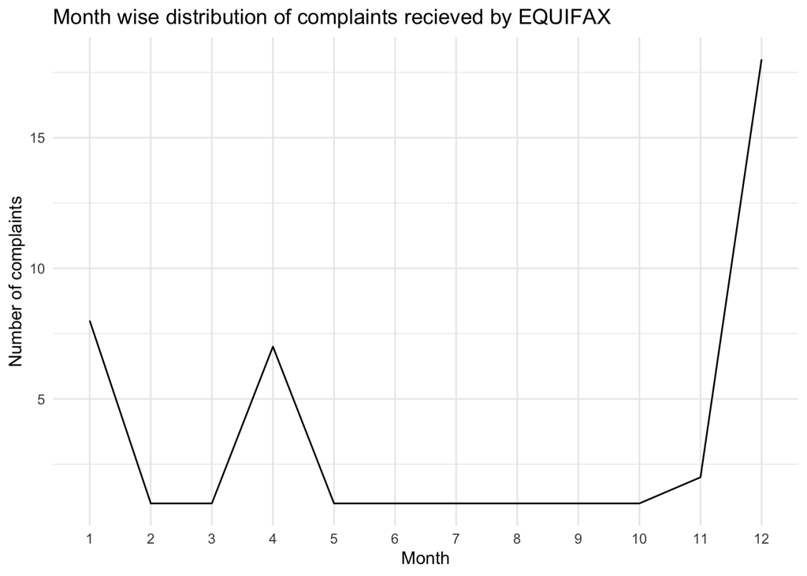

```r
ggplot(data = dataset.subset.1, aes(x = Date.received.month, y = total)) +
  geom_line() +
  ggtitle("Month wise distribution of complaints recieved by EQUIFAX") +
  xlab("Month") +
  ylab("Number of complaints") +
  scale_x_discrete(limits = c("1","2","3","4","5","6","7","8","9","10","11","12")) +
  theme_minimal()
```

```r
dataset.subset.2 <- dataset.summary %>%
  filter(Company == 'TRANSUNION INTERMEDIATE HOLDINGS, INC.')
dataset.subset.2 %>% kable() %>%
  kable_styling(full_width = F, position = "center", fixed_thead = T) %>%
  scroll_box(width = "100%", height = "100%")
```

| Company | Date.received.month | total |
| --- | --- | --- |
| TRANSUNION INTERMEDIATE HOLDINGS, INC. | 1 | 7 |
| TRANSUNION INTERMEDIATE HOLDINGS, INC. | 2 | 11 |
| TRANSUNION INTERMEDIATE HOLDINGS, INC. | 3 | 12 |
| TRANSUNION INTERMEDIATE HOLDINGS, INC. | 4 | 44 |
| TRANSUNION INTERMEDIATE HOLDINGS, INC. | 5 | 7 |
| TRANSUNION INTERMEDIATE HOLDINGS, INC. | 6 | 7 |
| TRANSUNION INTERMEDIATE HOLDINGS, INC. | 7 | 2 |
| TRANSUNION INTERMEDIATE HOLDINGS, INC. | 8 | 10 |
| TRANSUNION INTERMEDIATE HOLDINGS, INC. | 9 | 24 |
| TRANSUNION INTERMEDIATE HOLDINGS, INC. | 10 | 17 |
| TRANSUNION INTERMEDIATE HOLDINGS, INC. | 11 | 9 |
| TRANSUNION INTERMEDIATE HOLDINGS, INC. | 12 | 3 |

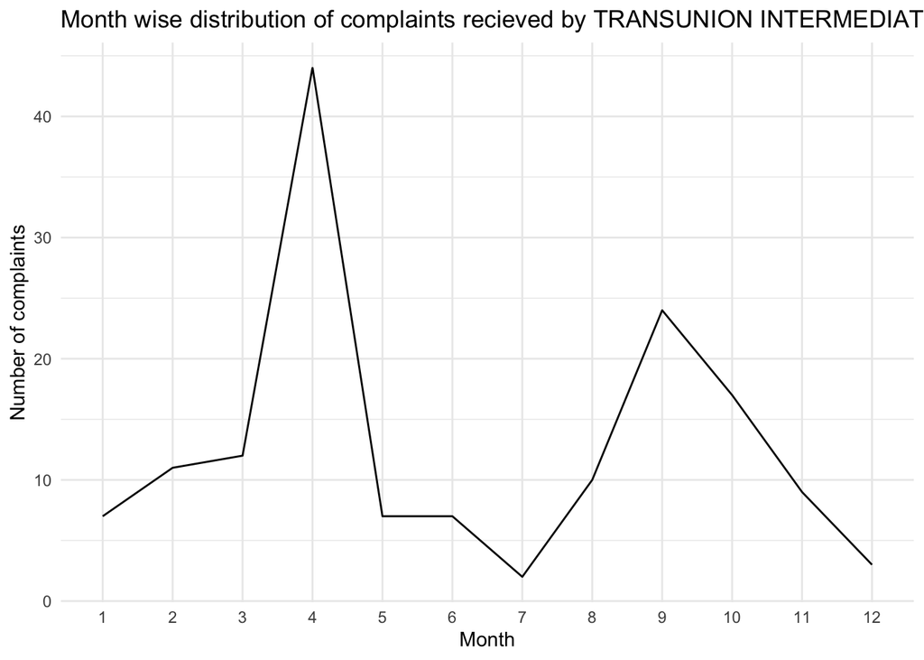

```r
ggplot(data = dataset.subset.2, aes(x = Date.received.month, y = total)) +
  geom_line() +
  ggtitle("Month wise distribution of complaints recieved by TRANSUNION INTERMEDIATE HOLDINGS, INC.") +
  xlab("Month") +
  ylab("Number of complaints") +
  scale_x_discrete(limits = c("1","2","3","4","5","6","7","8","9","10","11","12")) +
  theme_minimal()
```

### Replication

To make this process easy, I have developed this into a function. You have to pass the argument name of the company for which you need information and the function will return a table with summarised information and a plot for easy understanding.

```r
get_monthly_summary <- function(company_name){
  dataset.subset.temp <- dataset.summary %>%
    filter(Company == company_name)
  dataset.subset.temp %>% print()
  dataset.subset.temp %>% kable() %>%
    kable_styling(full_width = F, position = "center", fixed_thead = T) %>%
    scroll_box(width = "100%", height = "100%")
  ggplot(data = dataset.subset.temp, aes(x = Date.received.month, y = total)) +
    geom_line() +
    ggtitle("Month wise distribution of complaints recieved") +
    xlab("Month") +
    ylab("Number of complaints") +
    scale_x_discrete(limits = c("1","2","3","4","5","6","7","8","9","10","11","12")) +
    theme_minimal()
}
```

```r
get_monthly_summary('TRANSUNION INTERMEDIATE HOLDINGS, INC.')
```

```
## # A tibble: 12 x 3
## # Groups:   Company [1]
##    Company                                Date.received.month total
##    <fct>                                                <int> <int>
##  1 TRANSUNION INTERMEDIATE HOLDINGS, INC.                   1     7
##  2 TRANSUNION INTERMEDIATE HOLDINGS, INC.                   2    11
##  3 TRANSUNION INTERMEDIATE HOLDINGS, INC.                   3    12
##  4 TRANSUNION INTERMEDIATE HOLDINGS, INC.                   4    44
##  5 TRANSUNION INTERMEDIATE HOLDINGS, INC.                   5     7
##  6 TRANSUNION INTERMEDIATE HOLDINGS, INC.                   6     7
##  7 TRANSUNION INTERMEDIATE HOLDINGS, INC.                   7     2
##  8 TRANSUNION INTERMEDIATE HOLDINGS, INC.                   8    10
##  9 TRANSUNION INTERMEDIATE HOLDINGS, INC.                   9    24
## 10 TRANSUNION INTERMEDIATE HOLDINGS, INC.                  10    17
## 11 TRANSUNION INTERMEDIATE HOLDINGS, INC.                  11     9
## 12 TRANSUNION INTERMEDIATE HOLDINGS, INC.                  12     3
```

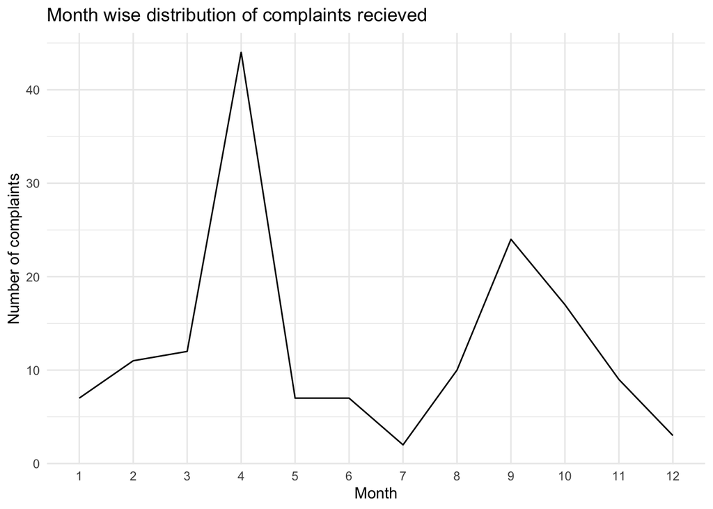

```r
get_monthly_summary('Experian Information Solutions Inc.')
```

```
## # A tibble: 11 x 3
## # Groups:   Company [1]
##    Company                             Date.received.month total
##    <fct>                                             <int> <int>
##  1 Experian Information Solutions Inc.                   1     1
##  2 Experian Information Solutions Inc.                   2     3
##  3 Experian Information Solutions Inc.                   3    16
##  4 Experian Information Solutions Inc.                   4    17
##  5 Experian Information Solutions Inc.                   5     5
##  6 Experian Information Solutions Inc.                   7     2
##  7 Experian Information Solutions Inc.                   8     3
##  8 Experian Information Solutions Inc.                   9     1
##  9 Experian Information Solutions Inc.                  10     1
## 10 Experian Information Solutions Inc.                  11     4
## 11 Experian Information Solutions Inc.                  12     4
```

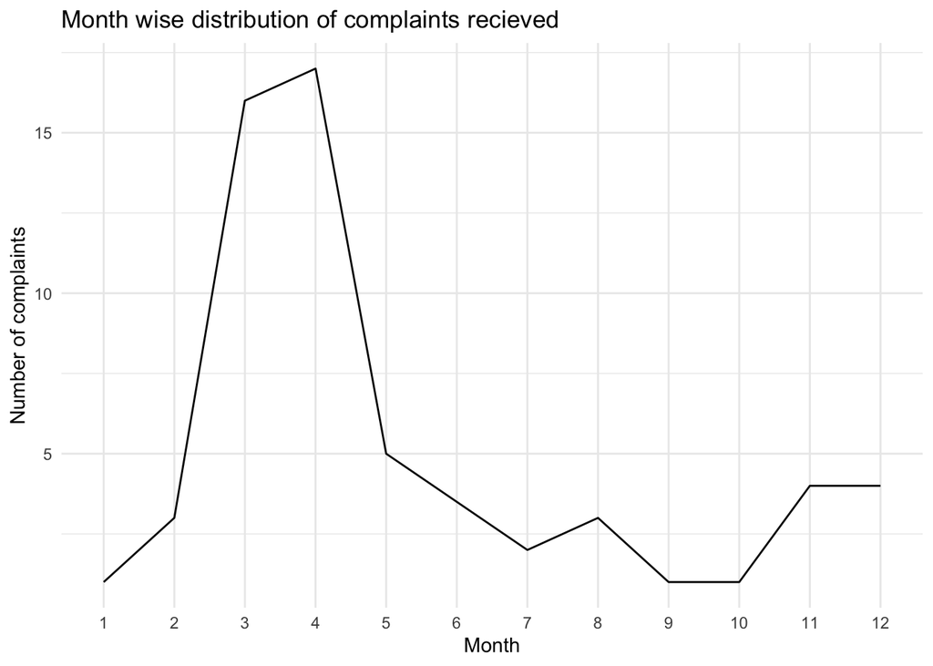

Summarising complaints for individual companies is helpful but let us see if there is a pattern in the overall complaints.

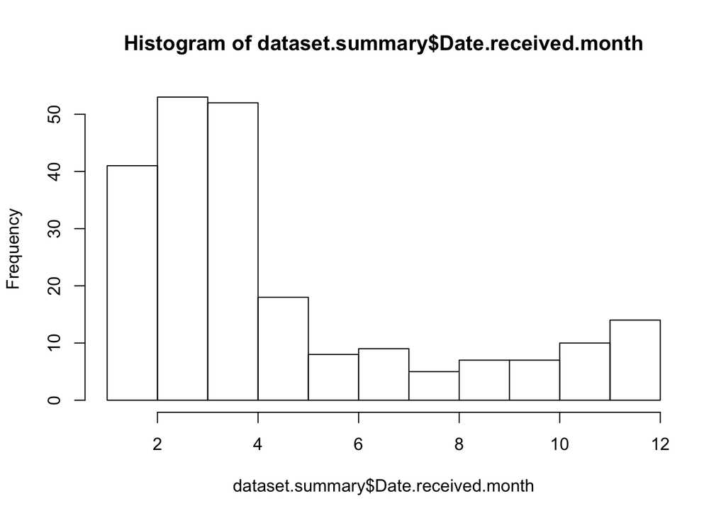

```r
hist(dataset.summary$Date.received.month)
```

Make a function which will return the word cloud of the most commonly used words for the complaints of a company.

```r
generate_wordcloud <- function(company_name){
  dataset.subset.temp <- dataset %>% filter(Company == company_name) %>% select(Consumer.complaint.narrative)
  #Create a vector containing only the text
  text.temp <- dataset.subset.temp$Consumer.complaint.narrative
  # Create a corpus
  docs.temp <- Corpus(VectorSource(text.temp))
  docs.temp <- docs.temp %>%
    tm_map(removeNumbers) %>%
    tm_map(removePunctuation) %>%
    tm_map(stripWhitespace)
  docs.temp <- tm_map(docs.temp, content_transformer(tolower))
  #removeXXXX = "XXXX"
  words_remove = c("xxxx", "xxxxxxxx", "xx")
  docs.temp <- tm_map(docs.temp, removeWords, stopwords("english"))
  docs.temp <- tm_map(docs.temp, removeWords, words_remove)
  dtm <- TermDocumentMatrix(docs.temp)
  matrix <- as.matrix(dtm)
  words <- sort(rowSums(matrix),decreasing=TRUE)
  df <- data.frame(word = names(words),freq=words)
  set.seed(1234) # for reproducibility
  wordcloud(words = df$word, freq = df$freq, min.freq = 1, max.words=200, random.order=FALSE, rot.per=0.35,            colors=brewer.pal(8, "Dark2"))
}
```

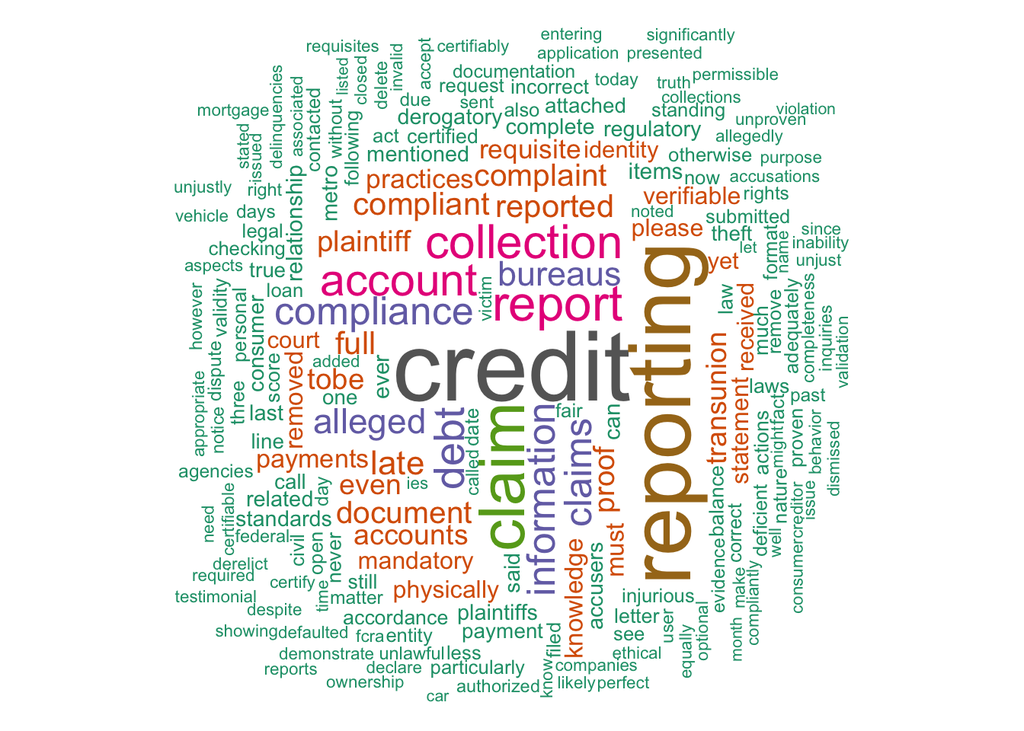

```r
generate_wordcloud('TRANSUNION INTERMEDIATE HOLDINGS, INC.')
```

### Key Takeaway 2:

The data seems to have blocked out data like XXXX which is showing up in the wordcloud. I had to manually remove words like those from the comments.

```r
head(dataset)
```

[output not shown]

[output cut: 62 more lines]

```r
# Company.response.to.consumer
# Product
# Sub.product - highly correlated with Product
# Issue
# Sub.issue - highly correlated with issue
# Consumer.complaint.narrative
# State ##Removing this post observation
# Consumer.consent.provided.
# Submitted.via ##removing this post observation

for(i in 1:nrow(dataset)){
  if(dataset$Consumer.complaint.narrative[i] == ""){
    dataset$Consumer.complaint.narrative.present[i] = 0
  } else {
    dataset$Consumer.complaint.narrative.present[i] = 1
  }
  if(dataset$Company.response.to.consumer[i] == "Closed with monetary relief"){
    dataset$Closed.with.monetary.relief[i] = 1
  }
  else {
    dataset$Closed.with.monetary.relief[i] = 0
  }
}


lm1 <- lm(Closed.with.monetary.relief ~ Product + Issue + Consumer.complaint.narrative.present + Consumer.consent.provided., data = dataset)
summary(lm1)
```

```
##
## Call:
## lm(formula = Closed.with.monetary.relief ~ Product + Issue +
##     Consumer.complaint.narrative.present + Consumer.consent.provided.,
##     data = dataset)
##
## Residuals:
##      Min       1Q   Median       3Q      Max
## -0.50948 -0.00575 -0.00073  0.00267  0.95754
##
## Coefficients: (6 not defined because of singularities)
##                                                                                        Estimate
## (Intercept)                                                                            0.481046
## ProductCredit card                                                                     0.500000
## ProductCredit card or prepaid card                                                     0.500000
## ProductCredit reporting, credit repair services, or other personal consumer reports    0.360728
## ProductDebt collection                                                                -0.490866
## ProductMoney transfer, virtual currency, or money service                              0.192785
## ProductMortgage                                                                       -0.491281
## ProductPayday loan, title loan, or personal loan                                      -0.494977
## ProductStudent loan                                                                    0.357488
## ProductVehicle loan or lease                                                           0.363864
## IssueApplying for a mortgage or refinancing an existing mortgage                      -0.002401
## IssueAttempts to collect debt not owed                                                -0.001392
## IssueCharged fees or interest you didn't expect                                        0.004454
## IssueClosing an account                                                               -0.319023
## IssueClosing on a mortgage                                                            -0.008719
## IssueClosing your account                                                             -0.993682
## IssueCommunication tactics                                                            -0.003140
## IssueCredit monitoring or identity theft protection services                          -0.855933
## IssueDealing with your lender or servicer                                             -0.724752
## IssueDisclosure verification of debt                                                  -0.009134
## IssueFalse statements or representation                                                0.138583
## IssueFees or interest                                                                 -0.657000
## IssueFraud or scam                                                                    -0.719569
## IssueGetting a credit card                                                            -0.994977
## IssueGetting a loan or lease                                                          -0.844909
## IssueIdentity theft protection or other monitoring services                           -0.860728
## IssueImproper use of your report                                                      -0.853307
## IssueIncorrect information on your report                                             -0.854976
```

[output cut: 252 more lines]

```
## IssueTrouble during payment process
## IssueUnable to get your credit report or credit score                                 ***
## IssueUnexpected or other fees                                                         **
## IssueVehicle was damaged or destroyed the vehicle
## IssueWritten notification about debt
## Consumer.complaint.narrative.present
## Consumer.consent.provided.Consent not provided
## Consumer.consent.provided.Consent provided
## Consumer.consent.provided.Other
## ---
## Signif. codes:  0 '***' 0.001 '**' 0.01 '*' 0.05 '.' 0.1 ' ' 1
##
## Residual standard error: 0.1451 on 449 degrees of freedom
## Multiple R-squared:  0.3895, Adjusted R-squared:  0.3215
## F-statistic: 5.728 on 50 and 449 DF,  p-value: < 2.2e-16
```

Plotting the variation between states and number of complaints that received monetary relief.

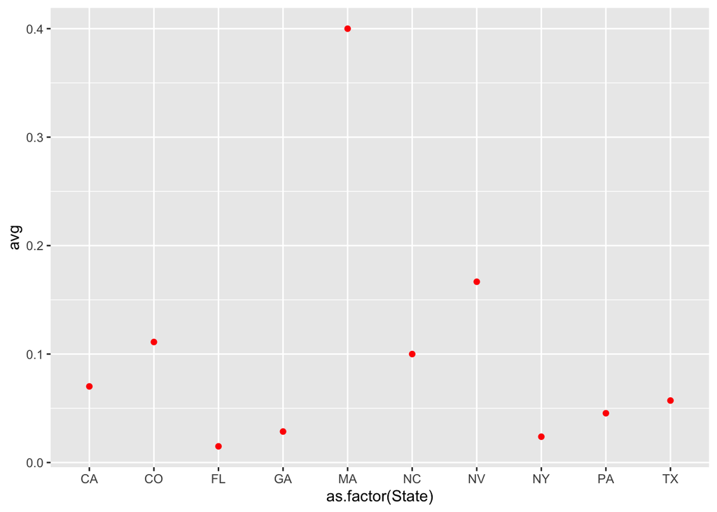

```r
#The states that had 0 monetary relief have been removed here for clarity in the graph.
dataset %>% group_by(State) %>% summarise(avg = mean(Closed.with.monetary.relief), total = n()) %>% filter(avg != 0) %>% arrange(desc(avg)) %>% ggplot(aes(x = as.factor(State), y = avg)) + geom_point(color = "red")
```